# Instant Gas Exchange Analysis (IGEA) package

## Introduction

Photosythesis rate, water conductance and Ci/Ca (intercellular to ambient CO2 partial pressures) are three key plant physiological parameters in terms of carbon simulation and water use efficiency ( [Lawson and Blatt, 2014](http://www.plantphysiol.org/content/plantphysiol/164/4/1556.full.pdf); [Ellsworth and Cousins, 2016](http://www.sciencedirect.com/science/article/pii/S1369526616300632?via%3Dihub) ). In short, I will refer these three parameters as “gas exchange parameters”" in the following context. They can be measured simultaneously using LI-6400XT Portable Photosynthesis System [(LiCor Inc. Lincoln Nebraska, USA)](https://www.licor.com/env/products/photosynthesis/LI-6400XT/). The actual measurement procedure is relatively complex, but the short story is that you place the machine right next to the plant, clamp the leaf into the chamber, and initiate the autolog program. LI-6400XT records all the input parameters in time series and does the calculation to get those parameters that we care about.

This R package is designed specifically for experimental projects that are currently going on in [Leakey Lab (UIUC)](https://lab.igb.illinois.edu/leakey/home). Recently Postoc Dr. Wertin applied a high-throughtput protocol for gas exchange measurements in this summer field season. The major improvement of this protocol involves harvesting leaves in the field and then conducting measurements in lab instead of taking the machine out in the field to the plants. This newer method allows us to measure more than 200 leafs (single 4-minute measurement on each leaf) per day, attributing to the fact that people don’t need to carry around the heavy machine in the field under harsh sunlight. After being harvested from field and take back to lab, each leaf is kept hydrated by inserting its cut wound side into a 10 ml tube full of water. Leaves are rotationally incubated for half an hour in two lighted growth chambers prior to measurements since it takes that long to activate each leaf and let them function happily. Recording leaf’s identity into LI-6400XT is done by adding “remarks” of leaf identity between two measurements. This is a bit old fashioned and also is where a big part of human errors come from that need to be fixed. Measurements are taken place after clamping the leaf for 4 minutes.

Example data provided in this tutorial is my real data collected in this summer. In order to better show the functions of my package as well as to have a reasonable data size, only a part of my dataset is provided here. My experimental design is a RCBD with 2 blocks. Within each block, each genotype has its plot and there are 2 biological sampled within each plot. Due to the fact that here is a partial dataset, total reps for most genotypes are less than 4.

The aim of this package is to provide a pipeline of treating the standard output table from LI-6400XT. Measurements are first reformated, merged and screened to see abnormal measurements in `read.GX` and `CS` function. Then curves can be plotted so that outliers can be spotted and found, using `plotGX` and `FindGX`. Values will be extracted from curves with function `GetValue`. At last `PGMean` is used to calculate plot means and genotype means. `summary` provide detailed information for corresponding class of data.

## read.GX

**(Read in Gas Exchange raw data)**

Once you copied the raw output table from LI-6400, turn it into csv file. My files have a naming convention of “Operator + date + population + machine .csv”. These data are provided in the same folder. These data has a long header, lots of parameters, ton of useless time remarks and relatively complicated structure. In short, they desperately need to be re-structured and re-organized.

If argument `condition` is `TRUE`, the measurement conditions will be checked and printed. Some machines doesn’t record all the conditions (like this case below). Warnings will pop out when the file has multiple conditions or incomplete conditions. Check or not, `GXcurve` file will include as many conditions as it recorded in the attributes.

```r
leak1_718 = read.GX(filename = "KX_07-18-2017_ril_leak1_.csv",leaf_rep = 1,genolist = "genotypic_information.csv", condition = TRUE)
```

```
## Warning in read.GX(filename = "KX_07-18-2017_ril_leak1_.csv", leaf_rep =
## 1, : Missing measuring conditions. Check data collection conditions.
```

```
## [1] "Flow: Fixed -> 400 umol/s"
```

Notice in this dataset some name “remarks” have only 2 digits (operator’s fault), which will cause trouble later. So all plot names have to unified into 3 digits.

```r
steward_718 = read.GX(filename = "TMW_07-18-2017_ril_stewart_.csv",leaf_rep = 1,genolist = "genotypic_information.csv")
```

```
## check out these names, are they 3 digits?
##  46 21
## Reformatting them into 3 digits...Done.
```

I omit the code of reading in the remaining csv files here. In total I read in 9 example dataset here: `leak1_718`, `leak2_718`, `steward_718`, `leak1_719`, `leak1_720`, `steward_720`, `leak1_721`, `leak2_721`, `steward_721`

Let’s take a look of the output.

```r
dim(leak1_718)
```

```
## [1] 2958   12
```

```r
head(leak1_718)
```

```
##   plot leaf  name FTime    Photo      Cond     Ci.Ca
## 1  120    1 120_1   0.0 26.64295 0.3362342 0.6404562
## 2  120    1 120_1   4.0 27.19798 0.3445699 0.6399731
## 3  120    1 120_1   8.0 27.89171 0.3523109 0.6374865
## 4  120    1 120_1  12.0 28.57598 0.3551665 0.6308909
## 5  120    1 120_1  16.5 28.92169 0.3582615 0.6288751
## 6  120    1 120_1  20.5 29.13794 0.3606656 0.6281220
##                            tag  genotype range row block
## 1 KX_07-18-2017_ril_leak1_.csv Z019E0032     4  17   1_3
## 2 KX_07-18-2017_ril_leak1_.csv Z019E0032     4  17   1_3
## 3 KX_07-18-2017_ril_leak1_.csv Z019E0032     4  17   1_3
## 4 KX_07-18-2017_ril_leak1_.csv Z019E0032     4  17   1_3
## 5 KX_07-18-2017_ril_leak1_.csv Z019E0032     4  17   1_3
## 6 KX_07-18-2017_ril_leak1_.csv Z019E0032     4  17   1_3
```

```r
str(leak1_718)
```

```
## Classes 'GXcurve' and 'data.frame':  2958 obs. of  12 variables:
##  $ plot    : chr  "120" "120" "120" "120" ...
##  $ leaf    : num  1 1 1 1 1 1 1 1 1 1 ...
##  $ name    : chr  "120_1" "120_1" "120_1" "120_1" ...
##  $ FTime   : num  0 4 8 12 16.5 ...
##  $ Photo   : num  26.6 27.2 27.9 28.6 28.9 ...
##  $ Cond    : num  0.336 0.345 0.352 0.355 0.358 ...
##  $ Ci.Ca   : num  0.64 0.64 0.637 0.631 0.629 ...
##  $ tag     : chr  "KX_07-18-2017_ril_leak1_.csv" "KX_07-18-2017_ril_leak1_.csv" "KX_07-18-2017_ril_leak1_.csv" "KX_07-18-2017_ril_leak1_.csv" ...
##  $ genotype: chr  "Z019E0032" "Z019E0032" "Z019E0032" "Z019E0032" ...
##  $ range   : chr  " 4" " 4" " 4" " 4" ...
##  $ row     : chr  "17" "17" "17" "17" ...
##  $ block   : chr  "1_3" "1_3" "1_3" "1_3" ...
##  - attr(*, "measurement_time")= chr "Tue Jul 18 2017 08:12:06"
##  - attr(*, "machine")= chr "PSC-238"
##  - attr(*, "lightsource")= chr "6400-02 or -02B LED Source"
##  - attr(*, "AD.avgtime")= chr "4"
##  - attr(*, "flow")= chr "Flow: Fixed -> 400 umol/s"
##  - attr(*, "par")= chr
##  - attr(*, "CO2_mixer")= chr
##  - attr(*, "Tblock")= chr
```

You can use `summary` to get some knowledge for `GXcurve` class objects such as meausurement counts, leaf rep number. Also you can take a look of parameter summary if `value_summary` is set to be `TRUE`, as well as experimental conditions if you pass a character condition name to argument `check_condition`. (choose from: measurement_time / machine / lightsource / AD.avgtime / flow / par / CO2_mixer / Tblock)

```r
summary(leak1_718,value_summary = TRUE, check_condition = "flow")
```

```
## [1] "Measurent count: 51"
## [1] "leaf number: 1  observation counts: 2958"
##
## ### Data set included:
## KX_07-18-2017_ril_leak1_.csv
## [1] "Summary for Photosynthesis rate:"
##    Min. 1st Qu.  Median    Mean 3rd Qu.    Max.
## -106.97   27.81   30.26   29.70   32.79   38.88
## [1] "Summary for water conductance:"
##    Min. 1st Qu.  Median    Mean 3rd Qu.    Max.
## 0.07171 0.22126 0.29248 0.29967 0.36324 0.65902
## [1] "Summary for Ci.Ca:"
##    Min. 1st Qu.  Median    Mean 3rd Qu.    Max.
##  0.2067  0.4348  0.5263  0.5117  0.5938  2.6480
##
## Looking at flow :
## [1] "Flow: Fixed -> 400 umol/s"
```

I want to add that, in short, in **IGEA** we call “Photosythesis” as “Photo”, “Water Conductance” as “Cond”, “intercellular to ambient CO2 partial pressures” as “Ci.Ca”

## CS

**(Combine and Screen)**

Combining means that two seperate `GXcurve` tables are merged based on rows due to the fact data structures should be the same after being read in. Also measurement condition attributes are deleted.

Since dataset usually has a huge size, it is nearly impossible to go through each measurement and screen for abnormal measurements caused by human errors. Generally there are three kinds of human errors: 1. Duplicate names. Ideally the name recording for leaves are unique. But it is possible that during operation people accidentally put in a wrong name, resulting to a name duplication for another leaf. 2. Miss name recording. As mentioned before names are recorded by inserting “remarks” in between two measurements. Sometimes people forgot to add remark, resulting to a too long meausrement for the first sample. 3. Recording Interruption. When recording, errors might occur or the position of leaf needs to be adjusted, thus leading to too few recording in that measurement.

Now we apply `CS` on my 9 seperate datasets. It will print out the measurements in each dataset and in total. In addition, if you have any one of the potential human errors mentioned above, you will know how many errors there are and the sample names for each error. One thing that I think is handy is that these human error information will be a part of attributes of the `GXcurve` table and you can easily extract these information and target their location in the next function `FindGX`.

```r
AllCurve = CS(leak1_718,leak2_718,leak1_719,leak1_720,leak1_721,leak2_721,steward_720,steward_721,steward_718)
```

```
## input 1 / KX_07-18-2017_ril_leak1_.csv : 51 entries
## input 2 / KX_07-18-2017_RIL_leak2_.csv : 49 entries
## input 3 / KX_07-19-2017_RIL_leak1.csv : 51 entries
## input 4 / nicole-7-20-2017-ril_leak1.csv : 54 entries
## input 5 / cm_07-21-2017_ril_leak1_.csv : 53 entries
## input 6 / cm_07-21-2017_ril_leak2_.csv : 53 entries
## input 7 / KX_07-20-2017_RIL_Stewart.csv : 50 entries
## input 8 / KX_07-21-2017_RIL_STEWARD_.csv : 48 entries
## input 9 / TMW_07-18-2017_ril_stewart_.csv : 52 entries
## overall combining 461 entries
##
## [1] ">>> Walch out! You have 7 case(s) in which you have duplicate entry names. Better check out raw data:"
## [1] "007_1" "117_1" "118_1" "169_1" "279_2" "326_2" "374_2"
## [1] ">>> Walch out! You have 1 case(s) in which you have too few( 49 ) gas exchange recordings. Better check out raw data:"
## [1] "016_1"
## [1] ">>> Walch out! You have 2 case(s) in which you have missing name recording between two seperate measurements Better check out raw data:"
## [1] "220_2" "373_1"
```

```r
dim(AllCurve)
```

```
## [1] 26839    12
```

## FindGX

**(Find Measurement Index in Dataset)**

`FindGX` is designed to locate the abnormal measurements or the measurement you are interested in. First argument you give it is the dataset that has the measurement you care about. Each raw dataset that was merged earlier has a tag indicating the raw dataset name, so it allows the function to trace back to the location in the original dataset. After that you can put in character name of the measurement.

```r
FindGX(AllCurve, id = "119_1")
```

```
##
## >>>1th sample name:119_1    issue: input
## [1] "2089th to 2146th observation (58 counts) in KX_07-18-2017_ril_leak1_.csv"
```

Input can also be a character vector.

```r
FindGX(AllCurve, c("119_1","110_1"))
```

```
##
## >>>1th sample name:119_1    issue: input
## [1] "2089th to 2146th observation (58 counts) in KX_07-18-2017_ril_leak1_.csv"
##
## >>>2th sample name:110_1    issue: input
## [1] "4632th to 4689th observation (58 counts) in KX_07-18-2017_RIL_leak2_.csv"
```

Since name list of the questionable measurements are stored in the `GXcurve` table attributes, we can easily pull it out by giving `TRUE` to arguments `DuplicateName`, `MissRecording` and `TooSmall` (corresponding to three types of human error mentioned above). After getting the location and taking a look of them, we can make a judgement call how to deal with them (ignore them? delete them? etc.)

```r
FindGX(AllCurve, DuplicateName = TRUE, MissRecording = TRUE, TooSmall = TRUE)
```

```
##
## >>>1th sample name:007_1    issue: Duplicate name
## [1] "4409th to 4466th observation (58 counts) in KX_07-18-2017_RIL_leak2_.csv"
## [2] "4516th to 4573th observation (58 counts) in KX_07-18-2017_RIL_leak2_.csv"
##
## >>>2th sample name:117_1    issue: Duplicate name
## [1] "1741th to 1798th observation (58 counts) in KX_07-18-2017_ril_leak1_.csv"
## [2] "24637th to 24694th observation (58 counts) in TMW_07-18-2017_ril_stewart_.csv"
##
## >>>3th sample name:118_1    issue: Duplicate name
## [1] "4690th to 4747th observation (58 counts) in KX_07-18-2017_RIL_leak2_.csv"
## [2] "24000th to 24057th observation (58 counts) in TMW_07-18-2017_ril_stewart_.csv"
##
## >>>4th sample name:169_1    issue: Duplicate name
## [1] "871th to 928th observation (58 counts) in KX_07-18-2017_ril_leak1_.csv"
## [2] "26666th to 26723th observation (58 counts) in TMW_07-18-2017_ril_stewart_.csv"
##
## >>>5th sample name:279_2    issue: Duplicate name
## [1] "15186th to 15243th observation (58 counts) in cm_07-21-2017_ril_leak2_.csv"
## [2] "16577th to 16634th observation (58 counts) in cm_07-21-2017_ril_leak2_.csv"
##
## >>>6th sample name:326_2    issue: Duplicate name
## [1] "11997th to 12054th observation (58 counts) in cm_07-21-2017_ril_leak1_.csv"
## [2] "17505th to 17562th observation (58 counts) in cm_07-21-2017_ril_leak2_.csv"
##
## >>>7th sample name:374_2    issue: Duplicate name
## [1] "12287th to 12344th observation (58 counts) in cm_07-21-2017_ril_leak1_.csv"
## [2] "12519th to 12576th observation (58 counts) in cm_07-21-2017_ril_leak1_.csv"
##
## >>>8th sample name:220_2    issue: Missrecording
## [1] "17563th to 17678th observation (116 counts) in cm_07-21-2017_ril_leak2_.csv"
##
## >>>9th sample name:373_1    issue: Missrecording
## [1] "10431th to 10546th observation (116 counts) in nicole-7-20-2017-ril_leak1.csv"
##
## >>>10th sample name:016_1    issue: too few observations
## [1] "4467th to 4515th observation (49 counts) in KX_07-18-2017_RIL_leak2_.csv"
```

## plotGX

**(Plot Curve against Time)**

After taking care of technical errors, we might want to know how our curves look like and identify outliers based on that. The arguments of `plotGX` might seem confusing, but once you learn about it, you will see it has a big flexibiliy of how you want to give it the inputs. By the way, this function is relied on `ggplot2`.

First argument is `trait`, which is straightforward. Choose one from “Photo”, “Cond” or “Ci.Ca”. One type of trait can be plotted at once.

Measurements of the same genotype will be plotted together, so that the outliers can stand out. PGN format Plots are saved into the working directory with a naming convention of “trait + genotype name.pgn”. A sentence will pop out when each genotypic categorized measurement graph is drawn.

1. Give a `GXcurve` class object to argument `table`. In this case every single measurement in this table will be ploted. This way will be helpful if you have a full dataset and want to plot out all the graphs at once. I don’t want this whole page to be covered with “>>> curve saved” reminders so I test this function in a artificial dataset instead of `AllCurve`.

```r
PlotExample = AllCurve[AllCurve$genotype %in% head(unique(AllCurve$genotype),3),]
plotGX(trait = "Photo", table = PlotExample )
```

```
## >>>>>>>>>>>>>> Z019E0032 Photo curve saved
```

```
## >>>>>>>>>>>>>> Z019E0131 Photo curve saved
```

```
## >>>>>>>>>>>>>> Z019E0142 Photo curve saved
```

2. Type in character name of a genotype to `genotype` and give `dataset` the table that contains the chosen genotype. Now measurements from only one genotype is plotted. That genotype must be in the dataset provided.

```r
plotGX(trait = "Cond", genotype = "Z019E0032", dataset = AllCurve )
```

```
## >>>>>>>>>>>>>> Z019E0032 Cond curve saved
```

Here is an example of how the output graph looks likt. “208_2” has obviously abnormal status so it is considered a potential outlier. Here genotype “Z019E0032” only has 3 reps due to the reason it is a partial dataset, so we need more evidence before we can decide which measurements are outliers.

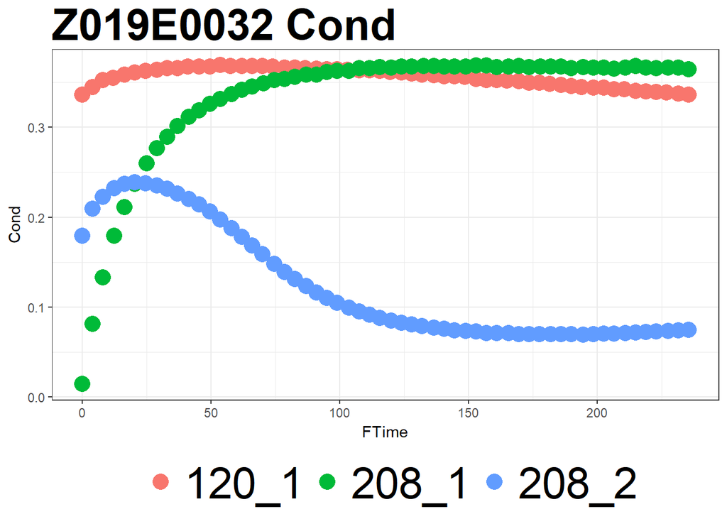

3. If you just want to look at a single measurement, you can type in character of the sample leaf to `id` and the dataset that contains it to `dataset`. id must be in the dataset provided.

```r
plotGX(trait = "Ci.Ca", id = "120_1" , dataset = AllCurve )
```

```
## >>>>>>>>>>>>>> Z019E0032 Ci.Ca curve saved
```

These three kinds of inputs have different scales, from biggest to smallest. Plotting can take some amount of time, take memories and could generate a longs list of PNG files, so it will be nice we can only plot the graphs that we want to look at.

## GetValue

**(Get first_minut and last_minute Values)**

There are two types of values we calculate and include in our further experiment (such as correlations with other traits etc.): First, we find the biggest “water conductance” value in the first minute and take the corresponding “Photosythesis” and “Ci/Ca” values; Second, we take the means of these three parameters in the last minute. Currently we don’t know which set of values are better representative but we hope further analysis will tell us more. You can choose to calculate both types of values by defalt or just one of them by setting `first.minute` or `last.minute` to `FALSE`. The first argument in the function should taka a `GXcurve` class table.

Each row in the output represents a single 4-minute measurement. This function returns a table of `GXvalue` class.

```r
AllValue = GetValue(AllCurve)
```

```r
head(AllValue)
```

```
##   plot_name leaf_name  name  genotype range row block Photo_first
## 1       120         1 120_1 Z019E0032     4  17   1_3    29.84656
## 2       132         1 132_1 Z019E0131     4   5   1_3    28.59743
## 3       035         1 035_1 Z019E0142     2  34   1_2    33.87819
## 4       111         1 111_1 Z019E0186     4  26   1_4    29.39469
## 5       058         1 058_1 Z019E0012     2  11   1_1    26.88869
## 6       174         1 174_1 Z019E0042     6  31   1_6    28.49013
##   Cond_first Ci.Ca_first Photo_last Cond_last Ci.Ca_last
## 1  0.3692671   0.6263136   29.86556 0.3431470  0.6013116
## 2  0.2847332   0.5517610   24.87349 0.1758160  0.4011134
## 3  0.4477515   0.6379621   33.92182 0.3656195  0.5682636
## 4  0.3546408   0.6201537   28.11929 0.2398602  0.4873725
## 5  0.2201143   0.4708115   28.34147 0.1639749  0.2680710
## 6  0.2461219   0.4910930   17.43624 0.1179347  0.3999248
```

```r
str(AllValue)
```

```
## Classes 'GXvalue' and 'data.frame':  454 obs. of  13 variables:
##  $ plot_name  : chr  "120" "132" "035" "111" ...
##  $ leaf_name  : num  1 1 1 1 1 1 1 1 1 1 ...
##  $ name       : chr  "120_1" "132_1" "035_1" "111_1" ...
##  $ genotype   : chr  "Z019E0032" "Z019E0131" "Z019E0142" "Z019E0186" ...
##  $ range      : chr  " 4" " 4" " 2" " 4" ...
##  $ row        : chr  "17" "5" "34" "26" ...
##  $ block      : chr  "1_3" "1_3" "1_2" "1_4" ...
##  $ Photo_first: num  29.8 28.6 33.9 29.4 26.9 ...
##  $ Cond_first : num  0.369 0.285 0.448 0.355 0.22 ...
##  $ Ci.Ca_first: num  0.626 0.552 0.638 0.62 0.471 ...
##  $ Photo_last : num  29.9 24.9 33.9 28.1 28.3 ...
##  $ Cond_last  : num  0.343 0.176 0.366 0.24 0.164 ...
##  $ Ci.Ca_last : num  0.601 0.401 0.568 0.487 0.268 ...
```

Apply `summary` function on `GXvalue` object could tell you what’s the total entry number, how balanced our dataset look like (based on leaf rep numbers) and a peek of selected trait.

```r
summary(AllValue, "Photo_first")
```

```
## [1] "454 entries"
## [1] "leaf number: 1  counts: 252" "leaf number: 2  counts: 202"
## [1] "Summary for Photo_first :"
##    Min. 1st Qu.  Median    Mean 3rd Qu.    Max.
##    7.27   28.54   30.71   30.59   33.28   40.04
```

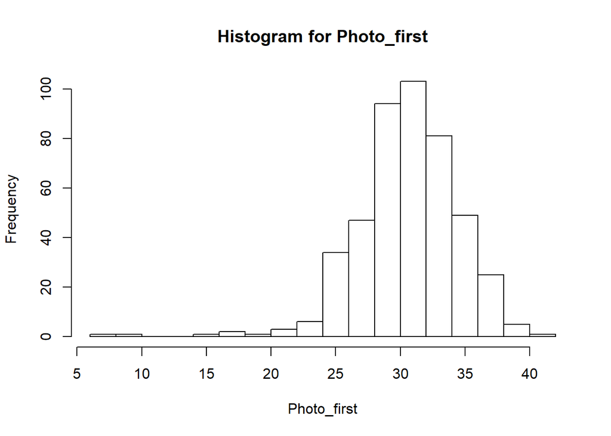

## PGMean

**(Plot or Genotype Mean)**

Once we got the values for each leaf sample, we can average the replicates in plots to get plot mean. Furthermore, since my experiment is RCBD with two blocks, I will need other softwares or packages to test for “block” effect and get BLUPs, but `PGMean` could still calculate genotype mean as a quick look.

It takes a `GXvalue` class table and you have to choose do you want “plot” mean or “genotype” mean. Standard errors are also calculated along with means. Due to the fact this example dataset is not complete, some plots only have 1 rep, so standard errors are left NA. In the end a `GXmean` class table is our output.

```r
All_Plot_Mean = PGMean.GXvalue(table = AllValue, type = "plot")
head(All_Plot_Mean)
```

```
##   Photo_first       se1 Cond_first       se2 Ci.Ca_first        se3
## 1    30.09407        NA  0.3071404        NA   0.5588554         NA
## 2    33.04417 0.4157424  0.4702737 0.1106128   0.6501093 0.06214361
## 3    30.13402        NA  0.4132270        NA   0.6567781         NA
## 4    31.95850        NA  0.4088973        NA   0.6315635         NA
## 5    28.85415        NA  0.2486149        NA   0.4889900         NA
## 6    29.51801        NA  0.4816661        NA   0.7049554         NA
##   Photo_last     se4 Cond_last       se5 Ci.Ca_last        se6 name
## 1   28.34812      NA 0.2225388        NA  0.4475159         NA  001
## 2   33.14915 1.33529 0.4248318 0.1080004  0.6159457 0.06487419  003
## 3   17.14521      NA 0.1079239        NA  0.3590968         NA  004
## 4   32.79355      NA 0.3319258        NA  0.5459090         NA  005
## 5   29.33462      NA 0.2160449        NA  0.4101836         NA  007
## 6   29.93719      NA 0.2746289        NA  0.5125430         NA  008
##   rep_number
## 1          1
## 2          2
## 3          1
## 4          1
## 5          1
## 6          1
```

```r
All_Geno_Mean = PGMean.GXvalue(table = AllValue, type = "genotype")
head(All_Geno_Mean)
```

```
##   Photo_first       se1 Cond_first        se2 Ci.Ca_first         se3
## 1    32.63358 2.4583080  0.4987503 0.06435379   0.6196301 0.048244139
## 2    29.66128 0.6510794  0.3202267 0.02122131   0.5663033 0.021493022
## 3    31.08139 0.6463155  0.3920433 0.01968533   0.6304771 0.006002226
## 4    29.47614 0.9086876  0.2467605 0.03130501   0.4600490 0.070707464
## 5    28.68134        NA  0.2316911         NA   0.4642242          NA
## 6    31.51549 2.9804679  0.3378364 0.09984724   0.5511694 0.072441474
##   Photo_last       se4 Cond_last        se5 Ci.Ca_last        se6
## 1   31.55617 2.7368705 0.4311308 0.06284513  0.5910306 0.04444923
## 2   25.09349 0.9985512 0.1902928 0.01231965  0.4276194 0.02065462
## 3   28.31636 3.6997958 0.2133319 0.03199015  0.4242808 0.00313067
## 4   24.22070 1.5096174 0.1565178 0.02174358  0.3448998 0.03522764
## 5   20.05882        NA 0.1263675         NA  0.3561975         NA
## 6   27.09388 6.1217865 0.2038045 0.06939495  0.4079320 0.04557627
##        name rep_number
## 1       B73         11
## 2      MS71         13
## 3 Z019E0002          2
## 4 Z019E0003          3
## 5 Z019E0004          1
## 6 Z019E0005          2
```

Apply `summary` function on `GXmean` object could give you a rough idea how our values look like, as well as how complete your dataset is(based on rep numbers). You probably noticed there are two genotypes that have way more reps than others, that’s my parents as checks in the field.

```r
summary(All_Geno_Mean, "Photo_first")
```

```
## There are 39 genotype(s) with 1 replicate(s)
## There are 70 genotype(s) with 2 replicate(s)
## There are 65 genotype(s) with 3 replicate(s)
## There are 14 genotype(s) with 4 replicate(s)
## There are 1 genotype(s) with 11 replicate(s)
## There are 1 genotype(s) with 13 replicate(s)
## [1] "Summary for Photo_first :"
##    Min. 1st Qu.  Median    Mean 3rd Qu.    Max.
##   16.95   28.83   30.53   30.56   32.49   40.04
```

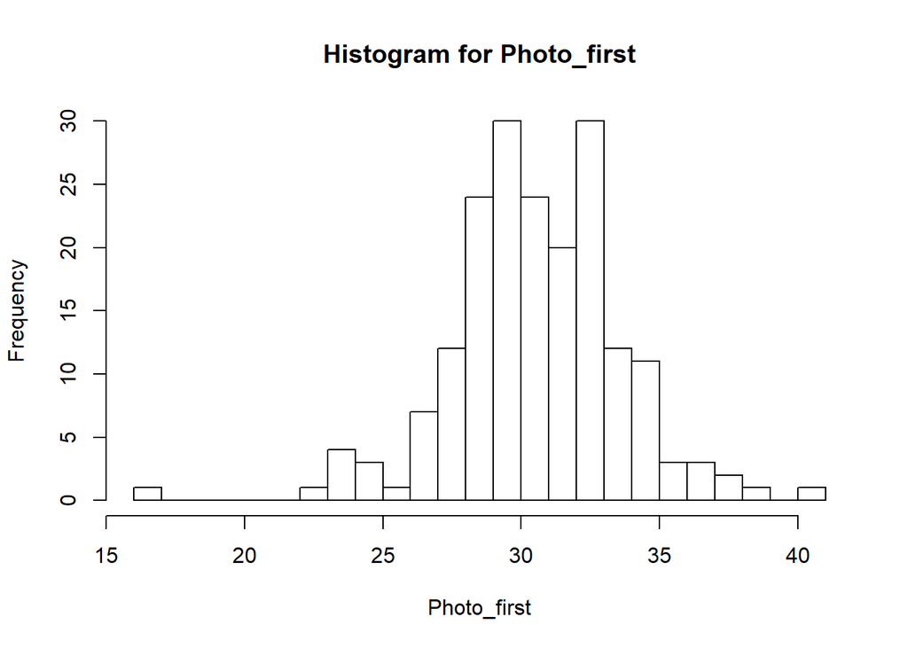